## In-class worksheet 3

**Jan 27, 2015**

## 1. Plotting the iris data set.

*Re-do question 3 from the homework with ggplot2: Make a scatter plot of petal length vs. sepal length for the three species. Then do the same plot but facet by species instead of coloring.*

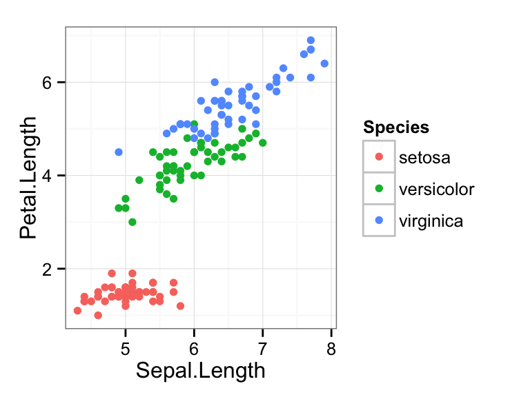

```r
ggplot(iris, aes(x=Sepal.Length, y=Petal.Length, color=Species)) + geom_point()
```

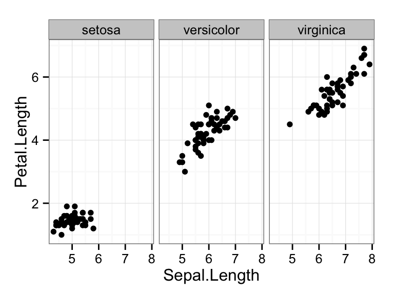

```r
ggplot(iris, aes(x=Sepal.Length, y=Petal.Length)) + geom_point() + facet_wrap(~Species)
```

*Now see if you can reproduce the answer to question 2 from the homework, using ggplot2. In other words, make side-by-side boxplots of sepal lengths for the three species of iris. The geom you need to use is `geom_boxplot()`. See if you can guess the correct aesthetic mapping.*

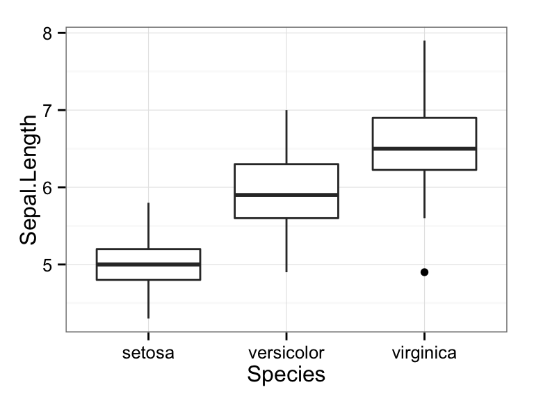

```r
ggplot(iris, aes(y=Sepal.Length, x=Species)) + geom_boxplot()
```

## 2. Plotting tree-growth data.

*The data set `Sitka` from the MASS package contains repeated measurements of tree size for 79 Sitka spruce trees, which were grown either in ozone-enriched chambers or under control conditions.*

```r
library(MASS) # we need to load the MASS library to have access to this dataset
head(Sitka)
```

```
##   size Time tree treat
## 1 4.51  152    1 ozone
## 2 4.98  174    1 ozone
## 3 5.41  201    1 ozone
## 4 5.90  227    1 ozone
## 5 6.15  258    1 ozone
## 6 4.24  152    2 ozone
```

*Make line plots of tree size vs. time, for each tree, faceted by treatment. First, use the same color for all lines.*

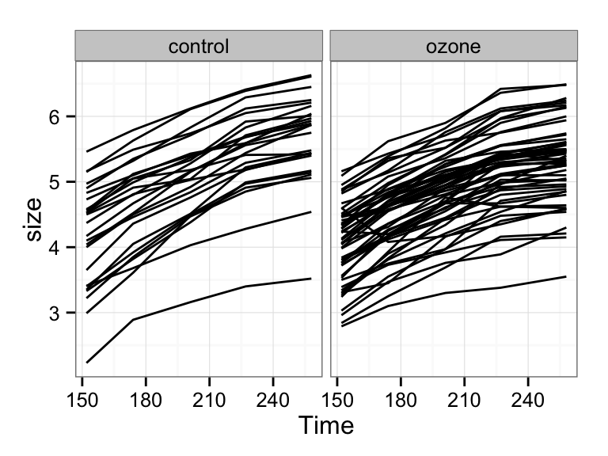

```r
ggplot(Sitka, aes(x=Time, y=size, group=tree)) + geom_line() + facet_wrap(~treat)
```

*Then, color by tree.*

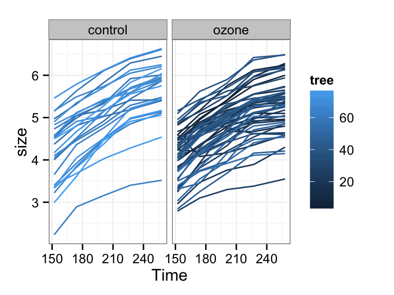

```r
ggplot(Sitka, aes(x=Time, y=size, color=tree, group=tree)) + geom_line() + facet_wrap(~treat)
```

*Finally, color by size.*

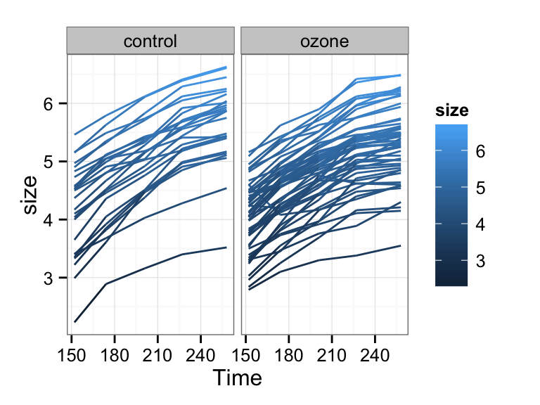

```r
ggplot(Sitka, aes(x=Time, y=size, color=size, group=tree)) + geom_line() + facet_wrap(~treat)
```

In this last example, the lines actually change color from left to right. It would be nicer to have a single, uniform color for each tree, and, e.g., color by maximum size. To do this efficiently we need the dplyr package, which we will discuss soon.

## 3. If this was easy

*Show the 2d distribution of petal length vs. sepal length in the `iris` dataset, by making an x-y plot that shows the individual data points as well as contour lines indicating the density of points in a given spatial region.*

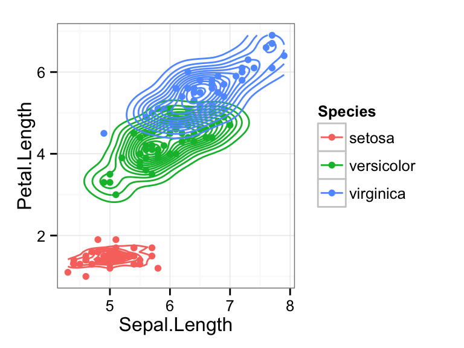

```r
ggplot(iris, aes(x=Sepal.Length, y=Petal.Length, color=Species)) + geom_point() + geom_density2d()
```

*If this was still easy, now instead of contour lines add a fitted straight black line (not a curve, and no confidence band!) to each group of points.*

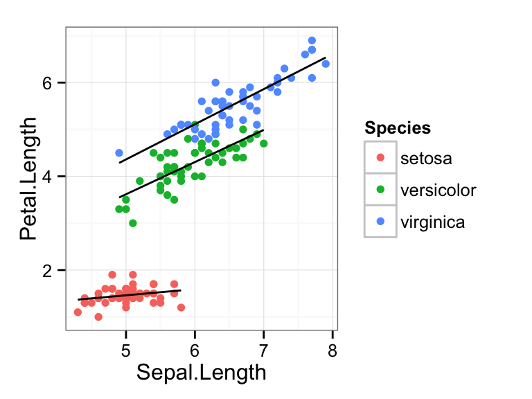

```r
ggplot(iris, aes(x=Sepal.Length, y=Petal.Length, color=Species)) + geom_point() + geom_smooth(aes(group=Species), method=lm, color='black', se=F)
```

In this last example, because we are manually overriding the color of the lines, we need to set the group aesthetic to tell ggplot2 to draw a separate line for each species.